# Tobin Predoctoral Data Task

Experiments to Enhance the Efficiency of Medicaid

Author

Sheena Tan

Published

May 1, 2024

**Github Repo Link**

https://github.com/sheena-tan/tobintask.git

# Introduction

This project uses data provided by Yale’s Tobin Center for Economic Policy as part of a data task for a pre-doctoral research position. For the first task, the data draws from a larger research project aiming to understand hospital response to reimbursement rate adjustment received as part of the Medicare Modernization Act (MMA) of 2003, and whether their adoption of medical technologies increased as a result of those adjustments. Task 2 uses sample Medicaid data to investigate the effects of managed care.

## Task 1

### Exercise 1

**Code (for reproducibility)**

```r
library(tidyverse)

# check missingness: n_missing = 0 for all variables
# check duplicates: n_unique = 1305 for both datasets
skimr::skim(mma_main)
skimr::skim(mma_treat)

# Clean primary key ----
mma_main_join <- mma_main |>
  mutate(prov_id = tolower(prov_id))

mma_treat_join <- mma_treat |>
  mutate(prov_id = tolower(prov_id))

# Join data ----
mma_data <- mma_treat_join |>
  left_join(mma_main_join)
```

An initial inspection of the data revealed no missingness. The provided data files were joined using provider ID as a primary key, resulting in a merged dataset with 13050 unique observations of 38 variables.

### Exercise 2

**Code**

```r
mma_data |>
  group_by(year) |>
  mutate(prov_total = n_distinct(prov_id)) |>
  skimr::skim(prov_total)
# N_t each year [2001-2010] constant = 1305

# create intermediate index variable before sum for all `tech_n`
for (i in 1:31) {
  mma_saidin <- mma_saidin |>
    group_by(year) |>
    mutate(
      # number of hospitals with tech_n
      !!paste0("sum_", i) := sum(!!sym(paste0("tech_", i))),
      # weight a_k,t
      !!paste0("weight_", i) := 1 - (1/1305) * !!sym(paste0("sum_", i)),
      !!paste0("index_", i) :=
        !!sym(paste0("tech_", i)) * !!sym(paste0("weight_", i))
    )
}

# sum across `index_n` to find saidin index for each hospital per year
mma_saidin <- mma_saidin |>
  pivot_longer(cols = starts_with("index"), names_to = "index") |>
  group_by(prov_id, year) |>
  summarise(sum(value)) |>
  rename(saidin = `sum(value)`)

# join to merged data
mma_data <- mma_saidin |>
  left_join(mma_data)
```

A variable `saidin` was constructed to represent the Saidin Index Score[^1] for all hospitals in each year and joined with the merged dataset to create the working dataset with **13050 observations** of **39 variables**. This index characterizes a hospital’s range of available technologies, weighted for their rarity, and provides a way through which to investigate how hospital technology grows and changes, particularly in response to interventions.

<sup>1</sup> Baker, L. & Spetz, J. (1999). Managed care and medical technology growth. *Frontiers in Health Policy Research, 2*, 31.

### Exercise 3

#### Part A

**Code**

```r
library(psych)

mma_2004 <- mma_data |>
  filter(year == 2004)

describe(mma_2004$saidin, IQR = TRUE, skew = FALSE)
```

**Summary Statistics**

```
   vars    n mean   sd median min   max range   se  IQR
X1    1 1305 1.93 2.01   1.19   0 11.57 11.57 0.06 1.84
```

The distribution of Saidin Index scores in 2004 is strongly right-skewed, with values ranging from **0 to 11.57**, a **median of 1.19**, and an **IQR of 1.84**.

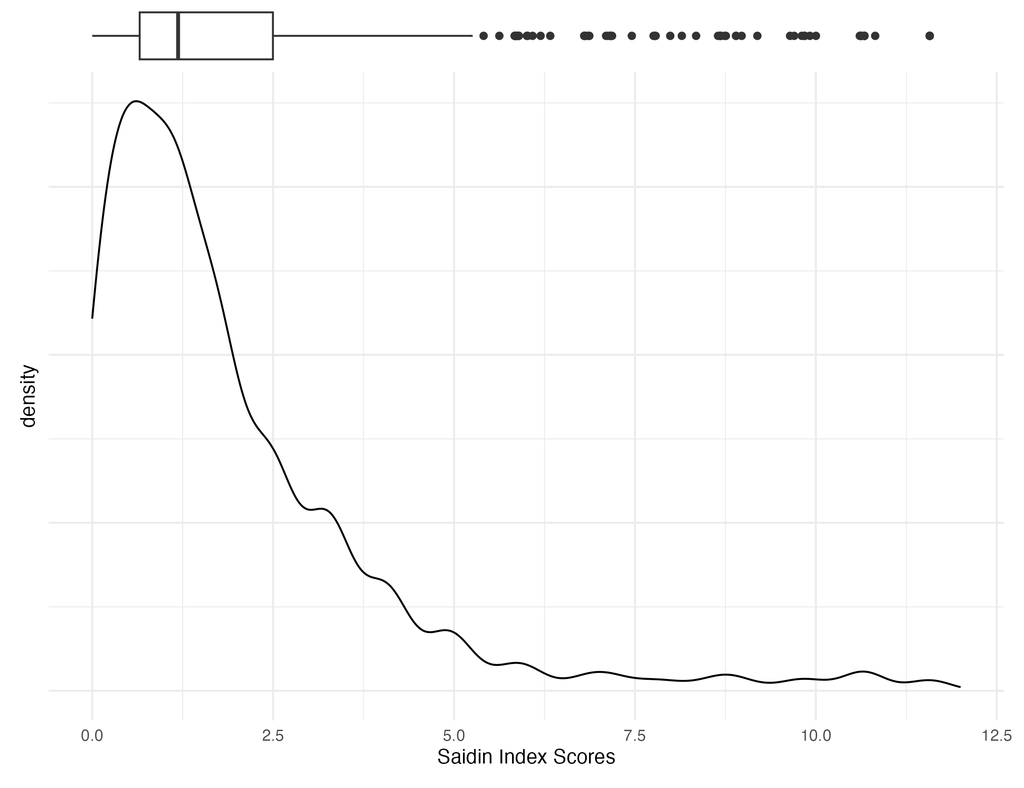

Figure 1: Density-boxplot of Saidin Index scores in 2004

As the Saidin Index is helpful for characterizing technology growth rates, the distributions by year can also be found below:

**ADDITIONAL EXPLORATORY ANALYSIS**

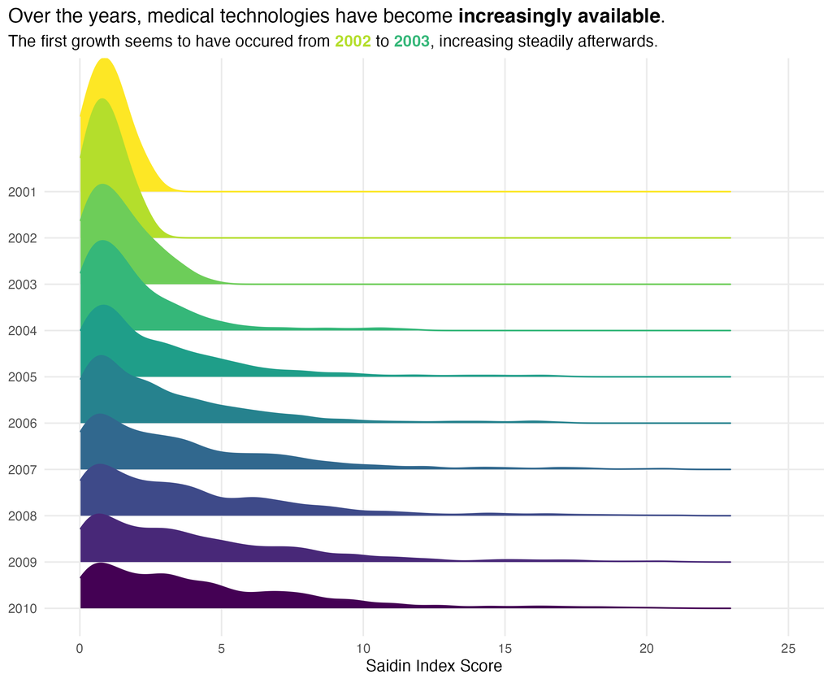

Figure 2: Density ridge plot of Saidin Index scores by year

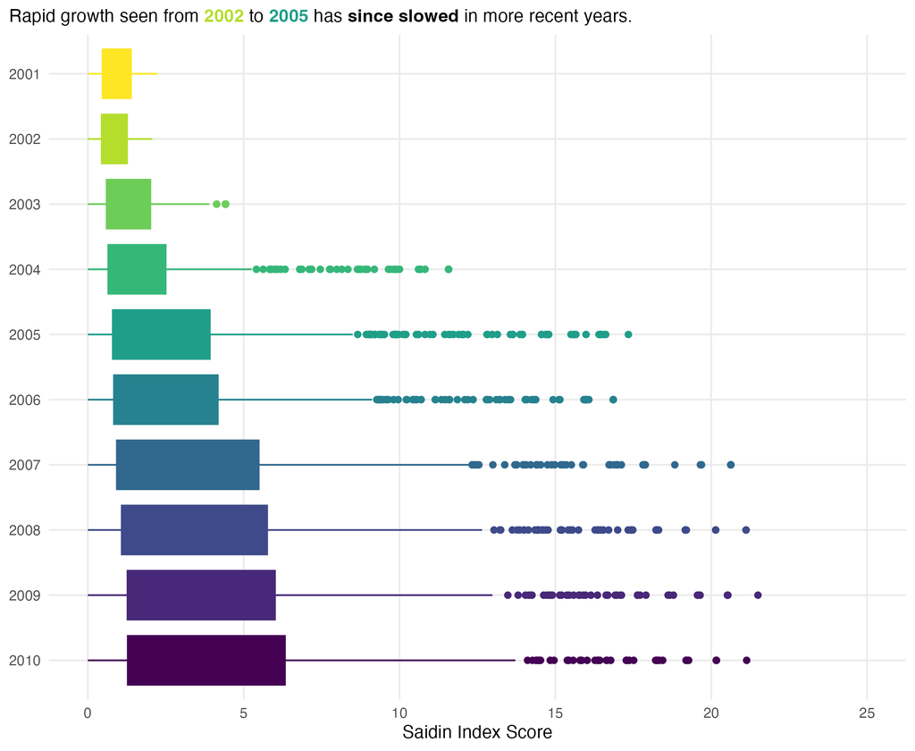

A period of rapid relative growth looks to have occurred between 2002 and 2005 (Figure 3), starting in 2003 (Figure 2), the same year that the Medicare Modernization Act (MMA) was initiated. However, this rapid growth has since slowed, with growth between 2007 and 2010 becoming increasingly limited.

It is also important to note that the scores have not shifted uniformly; rather, their distribution has become more spread out, with a large number of outliers developing on the higher end (better technology availability). Should these outliers correlate with those hospitals receiving MMA treatment, the data would suggest *support for the intervention’s positive impact*.

#### Part B

**Code**

```r
# create mutually exclusive type variable
mma_types <- mma_2004 |>
  mutate(
    hospital_type = case_when(
      nonprof == 1 & govt == 0 ~ "nonprof",
      govt == 1 & nonprof == 0 ~ "govt",
      govt == 0 & nonprof == 0 ~ "neither",
      TRUE ~ NA_character_
    )
  )

# assuming normality due to sample size: one-way ANOVA
anova_types <- aov(saidin ~ hospital_type, data = mma_types)
summary(anova_types)

# Tukey's test
TukeyHSD(anova_types)
```

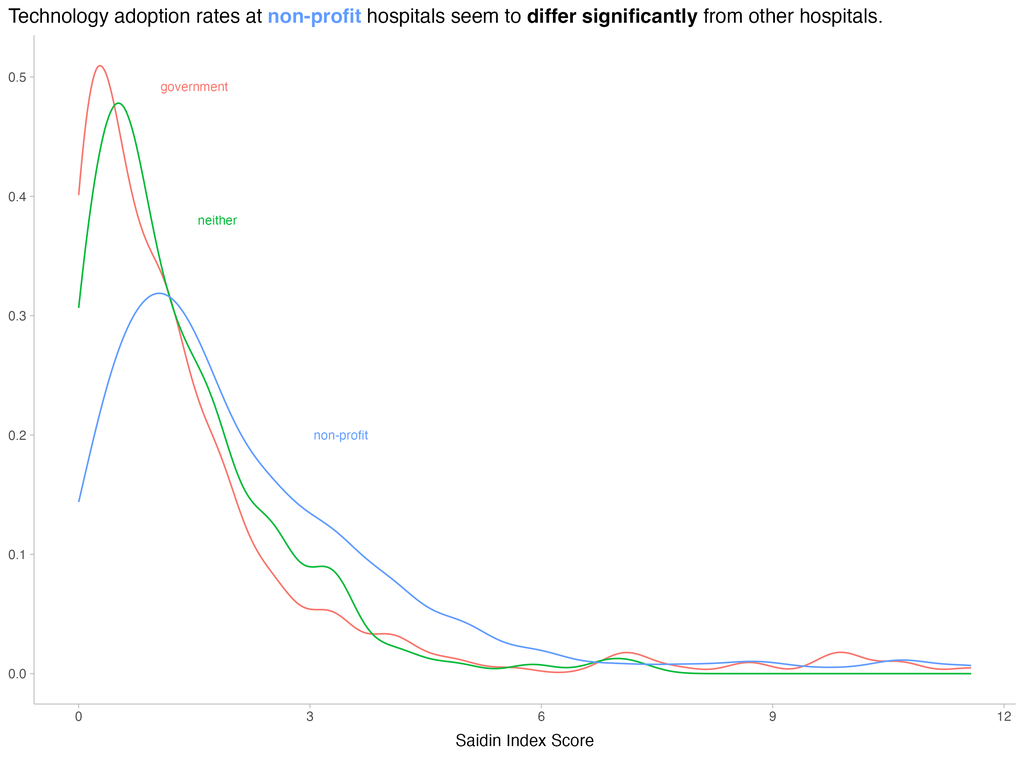

Figure 4: Density plots of Saidin scores by hospital type in 2004

Since the analysis was limited to 2004, I operationalize “rates of technology adoption” as the Saidin scores for that year. An initial density plot of Saidin scores by hospital type (i.e., nonprofit, government, neither) visualizes **seemingly significant differences** between non-profit hospitals and both other types. Government hospitals and hospitals that are neither non-profit nor government do not seem to differ much from each other.

To investigate if technology adoption rates were significantly different between the hospital types, I conduct a one-way ANOVA with the null hypothesis that the true difference in Saidin scores between hospital types is zero.

**ANOVA Results**

```
                Df Sum Sq Mean Sq F value   Pr(>F)
hospital_type    2    203  101.44   25.96 8.83e-12 ***
Residuals     1302   5088    3.91
---
Signif. codes:  0 '***' 0.001 '**' 0.01 '*' 0.05 '.' 0.1 ' ' 1
```

```
  Tukey multiple comparisons of means
    95% family-wise confidence level

Fit: aov(formula = saidin ~ hospital_type, data = mma_types)

$hospital_type
                      diff        lwr       upr     p adj
neither-govt    -0.1683424 -0.6144700 0.2777851 0.6496363
nonprof-govt     0.7553221  0.4399003 1.0707438 0.0000001
nonprof-neither  0.9236645  0.5355338 1.3117952 0.0000001
```

<sup>2</sup> In the Additional Exploratory Analysis callout in Part A

These results suggest that nonprofit hospitals have different (higher) rates of technology adoption than government hospitals or hospitals that are neither, implying the possibility for government hospital technology improvement.

#### Part C

**Code**

```r
# linear regression model
lm_beds <- lm(saidin ~ beds, data = mma_2004)
summary(lm_beds)
confint(lm_beds)
```

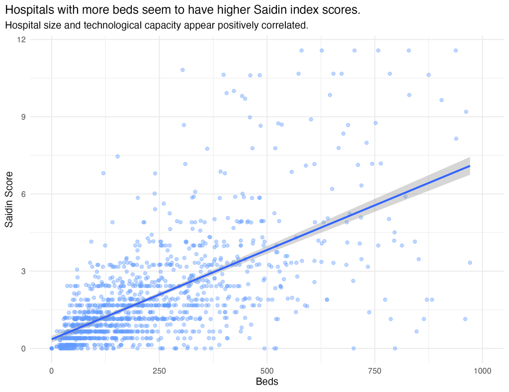

Figure 5: Scatterplot of Saidin scores and beds in 2004

An initial scatterplot of Saidin scores and beds in 2004 (i.e., nonprofit, government, neither) visualizes a **seemingly positive correlation** between hospital size and technological capacity.

Simple linear regression analysis was used to test if the number of beds explained variation in Saidin index scores.

**Linear Regression Results**

```
Call:
lm(formula = saidin ~ beds, data = mma_2004)

Residuals:
    Min      1Q  Median      3Q     Max
-9.7502 -0.7037 -0.2583  0.4577  8.4213

Coefficients:
             Estimate Std. Error t value Pr(>|t|)
(Intercept) 0.4783940  0.0645795   7.408  2.3e-13 ***
beds        0.0063164  0.0002105  30.013  < 2e-16 ***
---
Signif. codes:  0 '***' 0.001 '**' 0.01 '*' 0.05 '.' 0.1 ' ' 1

Residual standard error: 1.549 on 1303 degrees of freedom
Multiple R-squared:  0.4087,    Adjusted R-squared:  0.4083
F-statistic: 900.8 on 1 and 1303 DF,  p-value: < 2.2e-16
```

```
                  2.5 %      97.5 %
(Intercept) 0.351702766 0.605085256
beds        0.005903537 0.006729269
```

**Results**: A *significant* regression was found (*F*(1, 1303) = 900.8, *p* < 0.001). The R^2 value of **0.408** indicates that the predictor (`beds`) explained about 40.8% of the variation in Saidin index scores. We can be 95% certain that the true change in Saidin scores as a function of the number of beds is between **0.00590 and 0.00673**, suggesting a positive correlation.

These results support the idea that the more beds a hospital has, the higher their Saidin scores tend to be, suggesting that there is a positive relationship between hospital capacity and technological availability. One possible non-causal explanation for these findings could be that hospital capacity indicates greater access to resources, which also leads to higher rates of technology adoption.

### Exercise 4

**Code**

```r
library(fixest)

# event study model
did_event <-
  feols(saidin ~ i(year, treat, ref = 2004) | prov_id + year, data = mma_data)

# table of estimates and CI
did_estimates <- summary(did_event)
did_ci <- confint(did_event)

did_estimates_ci <- did_estimates$coefficients |>
  as.data.frame() |>
  tibble::rownames_to_column("year") |>
  left_join(
    as.data.frame(did_ci) |>
      tibble::rownames_to_column("year") |>
      rename(),
    by = join_by(year)
  ) |>
  janitor::clean_names() |>
  rename(
    tr_effect = did_estimates_coefficients,
    tr_hi = x97_5_percent,
    tr_lo = x2_5_percent
  ) |>
  mutate(year = as.numeric(str_extract(year, "\\d{4}")))

# table of means
did_means <- mma_data |>
  group_by(year) |>
  filter(treat == 0) |>
  summarize(mean(saidin)) |>
  rename(cr_mean = `mean(saidin)`) |>
  left_join(
    mma_data |>
      group_by(year) |>
      filter(treat == 1) |>
      summarize(mean(saidin)) |>
      rename(tr_mean = `mean(saidin)`)
  )

# join tables into new dataset
mma_did <- did_estimates_ci |>
  left_join(did_means)
```

Effect of MMA on adoption of medical technologies

Estimates from **fixest::feols()** with **95% CI**

|  | cr_mean | tr_mean | tr_effect | tr_lo | tr_hi |
| --- | --- | --- | --- | --- | --- |
| 2001 | 0.9732041 | 1.242174 | -1.7158315 | -2.5583887 | -0.8732743 |
| 2002 | 0.9235935 | 1.246545 | -1.6618503 | -2.4891736 | -0.8345270 |
| 2003 | 1.3741586 | 2.379339 | -0.9796213 | -1.7485591 | -0.2106836 |
| 2004 | 1.8862926 | 3.871094 | 0.0000000 | 0.0000000 | 0.0000000 |
| 2005 | 2.7596100 | 5.789187 | 1.0447754 | 0.4560094 | 1.6335414 |
| 2006 | 2.9447466 | 6.190351 | 1.2608024 | 0.5616288 | 1.9599761 |
| 2007 | 3.6669473 | 7.837037 | 2.1852883 | 1.2942542 | 3.0763225 |
| 2008 | 3.8583797 | 8.177011 | 2.3338304 | 1.4992070 | 3.1684538 |
| 2009 | 4.1152429 | 8.938300 | 2.8382556 | 1.8997108 | 3.7768004 |
| 2010 | 4.2149695 | 9.001277 | 2.8015062 | 1.7721967 | 3.8308157 |

The `fixest::feols()` function was used to estimate a fixed effects linear regression model with clustered standard errors as part of a difference-in-difference analysis, to estimate the effect (`tr_effect`) of receiving a Section 508 waiver on the adoption of medical technologies with 95% confidence interval bounds (`tr_lo`, `tr_hi`).

Mean Saidin index scores were also calculated for the control group (`cr_mean`) and treatment group (`tr_mean`) in each year.

### Exercise 5

**Code**

```r
library(ggtext)

# 95 CI error bars
mma_test <- mma_did |>
  filter(year >= 2004) |>
  mutate(
    tr_ref = tr_mean - tr_effect,
    tr_ref_lo = tr_mean - tr_hi,
    tr_ref_hi = tr_mean - tr_lo
  ) |>
  full_join(
    mma_did |>
      filter(year < 2004)
  )

# visualization: significant effect
did_plot <- mma_test |>
  ggplot(aes(year)) +
  geom_line(aes(y = cr_mean), color = "#619CFF", alpha = 0.5) +
  geom_point(aes(y = cr_mean), color = "#619CFF") +
  geom_line(aes(y = tr_ref), color = "#00BA38", linetype = "dashed", alpha = 0.7) +
  geom_point(aes(y = tr_ref), color = "#00BA38") +
  geom_errorbar(aes(ymin = tr_ref_lo, ymax = tr_ref_hi), color = "#00BA38", width = 0.1) +
  geom_ribbon(aes(ymin = tr_ref_lo, ymax = tr_ref_hi), fill = "#00BA38", alpha = 0.1) +
  geom_point(aes(y = tr_mean), color = "#F8766D") +
  geom_line(aes(y = tr_mean), color = "#F8766D", alpha = 0.5) +
  geom_vline(xintercept = 2004, linetype = "dotted") +
  scale_x_continuous(n.breaks = 9) +
  scale_y_continuous(n.breaks = 6) +
  theme_minimal() +
  theme(
    panel.grid.minor.x = element_blank(),
    axis.title.x = element_blank(),
    plot.title.position = "plot",
    plot.title = element_markdown(),
    plot.subtitle = element_markdown()
  ) +
  labs(
    y = "Saidin Index Scores",
    title = "Technology adoption rates
    <b style='color: #000000;'>significantly increase </b><b style='color: #00BA38;'>before</b>
    and <b style='color: #F8766D;'>after</b> MMA."
  ) +
  annotate("text", x = 2008, y = 3.5, label = "control", color = "#619CFF", size = 3) +
  annotate("text", x = 2005.2, y = 6.4, label = "treatment", color = "#F8766D" , size = 3) +
  annotate("text", x = 2009.1, y = 7.4, label = "counterfactual", color = "#00BA38" , size = 2.7) +
  annotate("text", x = 2004, y = 8.5, label = "Year of\nAdoption", size = 3)
```

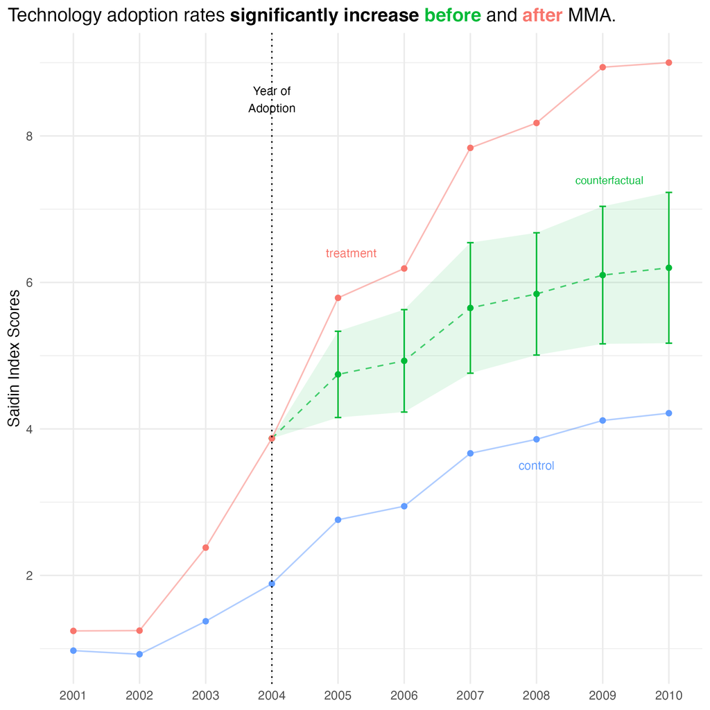

Figure 6: Difference-in-Differences Model

The difference-in-difference model suggests that Section 508 waivers resulted in a *significant increase in technology adoption rates* in hospitals. We see in Figure 6 that after accounting for treatment effects, the yearly means of the treatment group after the policy intervention in 2004 still **differ significantly** (95% CI) from the yearly means of the counterfactual group.

### Exercise 6

From the results of our difference-in-difference analysis, we can be 95% confident that MMA reimbursement rate adjustments had a positive impact on hospital technology adoption. As visualized in Figure 6, the yearly means of the treatment group still differed significantly from the counterfactual, or what would have been the treatment group without the effects of the policy intervention.

In our analysis we assume that:

1. in the absence of the policy intervention, the average outcomes of the treatment and control groups would have followed parallel paths over time;
2. there were no concurrent events or shocks occurring at the same time as the treatment that could have independently affected the outcome variable; and
3. the effect of the treatment did not become significantly stronger over time.

In the event that these assumptions do not hold, the difference-in-differences estimator would no longer be valid, as the differences in the trends would not be able to be attributed to the treatment itself and the treatment alone.

<sup>3</sup> [Center on Budget and Policy Priorities (2017)](https://www.cbpp.org/research/the-legacy-of-the-2001-and-2003-bush-tax-cuts#_ftn13)

## Task 2

### Exercise 1

**Code**

```r
library(tidyverse)
library(here)
library(tseries)

# Inspect data ----
skimr::skim(healthcare_data)

# confirm random auto-assignment
dummy_auto <- healthcare_data |>
  mutate(plan = ifelse(plan == "Plan_A", 1, 0)) |>
  filter(assignment_type == "Automatically Assigned")

runs.test(as.factor(dummy_auto$plan))

# test for random choice
dummy_choice <- healthcare_data |>
  mutate(plan = ifelse(plan == "Plan_A", 1, 0)) |>
  filter(assignment_type == "Member Choice")

runs.test(as.factor(dummy_choice$plan))
```

The data was read in and all character variables were retyped as factors, resulting 21300 observations of 7 variables. An initial inspection of the data revealed no missingness, duplicates, or extreme imbalance between levels.

A runs test completed using function `tseries::runs.test()` provides support for randomness in the plan assignment for automatically assigned Medicaid members. The test was non-significant at a 95% confidence level (*p* = **0.1999**), meaning that we do not reject the null hypothesis that the data is random.

The same method was used to test for randomness in the plan assignment for Medicaid members who chose their plan. The test was also non-significant at a 95% confidence level (*p* = **0.709**), meaning that we do not reject the null hypothesis that the data is random.

The higher p-value for the choice assignment versus automatic assignment could be due to differences in sample size. The larger the sample size, the more normal the distribution will be. Since the automatically assigned Medicaid members were the minority, there could have been more natural variation, resulting in the appearance of less randomness.

### Exercise 2

**Code**

```r
library(MatchIt)
library(marginaleffects)

# propensity score matching
psm_quick <-
  matchit(
    plan ~ gender + assignment_type + health_status + language,
    data = healthcare_data,
    method = "quick",
    estimand = "ATE"
  )

# check balance
plot(psm_quick, type = "density", interactive = FALSE,
     which.xs = ~ assignment_type + health_status + language)

plot(summary(psm_quick))

# estimate ATE
psm_data <- match.data(psm_quick)

psm_fit <- glm(
  healthcare_spend ~ plan * (gender + assignment_type + health_status + language),
  data = psm_data, weights = weights
)

avg_comparisons(
  psm_fit,
  variables = "plan",
  wts = "weights"
  )
```

[output not shown]

I chose to use propensity score matching to obtain a causal estimate of the managed care plan’s effect on health care spending. My motivation was to match individuals in Plan A with individuals in Plan B who have similar observable characteristics (e.g., demographics) but differ in plan assignment. I could then attribute differences in healthcare spending between the matched individuals to the causal effect of plan assignment.

In the analysis, Plan B was considered the treatment, and Plan A the control, such that the estimate would describe the difference in spending between Plan B - Plan A.

I chose to use the general full matching method `quick` using the `MatchIt::matchit()` function with logistic regression, because we are looking to find the average treatment effect (ATE) of categorical variable in a large dataset. This matching specification yielded exact balance. In other words, the absolute standard mean difference between matched pairs was zero for all predictors (See Figure 7). Full matching uses all treated and all control units, so no units were discarded by the matching.

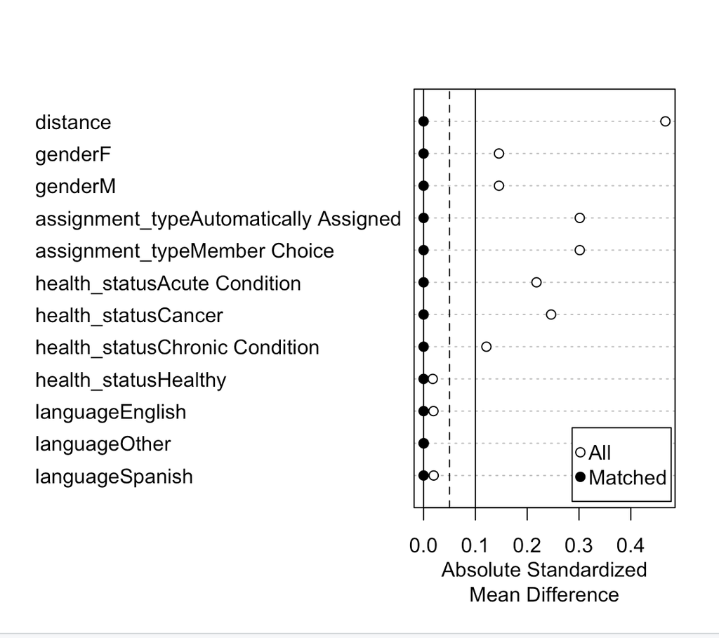

Figure 7: Love plot before and after PSM

### Exercise 3

**Code**

```r
# simple average
aggregate(healthcare_spend ~ plan, data = healthcare_data, FUN = mean)

# regression model with fixed effects
lm_fit <- glm(healthcare_spend ~ plan + gender + health_status + language, data = healthcare_data)

summary(lm_fit)
```

**Why the difference?** This discrepancy could be the result of confounding factors that are not taken into consideration in this simple average analysis, like the demographic variables, which may also directly impact spending and be distributed differently across each plan. For example, someone with a particular health condition might prefer one plan over another, but that health condition may also require significantly more spending than someone without that health condition.

### Exercise 4

**Code**

```r
# modified psm_fit
psm_fit_fixed <- glm(
  healthcare_spend ~ plan + gender + health_status + language,
  data = psm_data, weights = weights
)

avg_comparisons(
  psm_fit_fixed,
  variables = "plan",
  wts = "weights"
)
```

Using fixed effects rather than the interaction terms in the causal model from Question 2 does not impact the causal estimate. Since both fixed effects and interaction terms aim to control for potential confounding factors in the causal model, the lack of impact could mean that the treatment effect is homogenous across different levels of the covariates. In other words, controlling for fixed effects to deal with the confounding may already adequately explain the variation in spending across plans.

### Thank you for your time and consideration!